# Homeworks

Example #1 (Regression)

```r
ctl <- c(4.17,5.58,5.18,6.11,4.50,4.61,5.17,4.53,5.33,5.14)
trt <- c(4.81,4.17,4.41,3.59,5.87,3.83,6.03,4.89,4.32,4.69)
group <- gl(2, 10, 20, labels = c("Ctl","Trt"))
weight <- c(ctl, trt)
# estimated by OLS
lm.D9 <- lm(weight ~ group)
summary(lm.D9)
```

```
##
## Call:
## lm(formula = weight ~ group)
##
## Residuals:
##     Min      1Q  Median      3Q     Max
## -1.0710 -0.4938  0.0685  0.2462  1.3690
##
## Coefficients:
##             Estimate Std. Error t value Pr(>|t|)
## (Intercept)   5.0320     0.2202  22.850 9.55e-15 ***
## groupTrt     -0.3710     0.3114  -1.191    0.249
## ---
## Signif. codes:  0 '***' 0.001 '**' 0.01 '*' 0.05 '.' 0.1 ' ' 1
##
## Residual standard error: 0.6964 on 18 degrees of freedom
## Multiple R-squared:  0.07308,    Adjusted R-squared:  0.02158
## F-statistic: 1.419 on 1 and 18 DF,  p-value: 0.249
```

The $R^2$ is 0.0730776

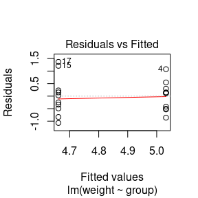

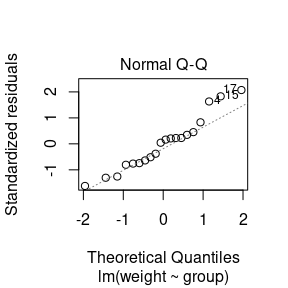

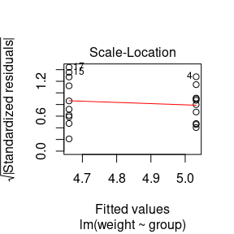

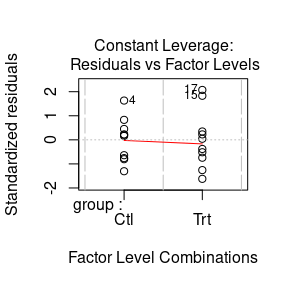

```r
# residual plots
plot(lm.D9)
```

Example #2  
Some information of dataset iris is shown below:

```r
xtable::xtable(head(iris))
```

```
## % latex table generated in R 3.6.3 by xtable 1.8-4 package
## % Sun Dec 20 09:25:21 2020
## \begin{table}[ht]
## \centering
## \begin{tabular}{rrrrrl}
##   \hline
##  & Sepal.Length & Sepal.Width & Petal.Length & Petal.Width & Species \\
##   \hline
## 1 & 5.10 & 3.50 & 1.40 & 0.20 & setosa \\
##   2 & 4.90 & 3.00 & 1.40 & 0.20 & setosa \\
##   3 & 4.70 & 3.20 & 1.30 & 0.20 & setosa \\
##   4 & 4.60 & 3.10 & 1.50 & 0.20 & setosa \\
##   5 & 5.00 & 3.60 & 1.40 & 0.20 & setosa \\
##   6 & 5.40 & 3.90 & 1.70 & 0.40 & setosa \\
##    \hline
## \end{tabular}
## \end{table}
```

Example #3  
Taylor expansion:  
$f(x)=f(x_0)+f'(x_0)(x-x_0)+\frac{f''(x_0)}{2!}(x-x_0)^2+\cdots+\frac{f^{(n)}(x_0)}{n!}(x-x_0)^n+R_n(x)$  
where $R_n(x)=\frac{f^{(n+1)}(\xi)}{(n+1)!}(x-x_0)^{n+1}$,$\xi\in(x_0,x)$

## Question

Exercises 3.3, 3.9, 3.10, and 3.13 (pages 94-95, Statistical Computating with R).

## Answer

#### Exercise 3.3

**Solution:** First, derive the inverse of cdf $F(x)$ of Pareto($a$,$b$).
$$\begin{align*}
& y=F(x)=1-\left(\frac{b}{x}\right)^a,\quad x\ge b>0,a>0 \\
& \Rightarrow \left(\frac{b}{x}\right)^a=1-y \\
& \Rightarrow x=b(1-y)^{-1/a} \\
& \Rightarrow F^{-1}(y)=b(1-y)^{-1/a},\quad 0\leq y\leq 1
\end{align*}$$
The algorithm steps for inverse transform method are as follows: $(a=2,b=2)$
**Step1:** Generate $u_i∼U[0,1],\,i=1,2,..,n$;
**Step2:** Return $X_i:=F^{-1}(u_i)=,2(1-u_i)^{-1/2},\,i=1,2,..,n$.

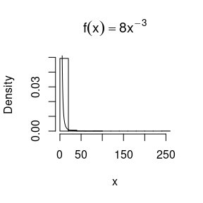

```r
set.seed(1)
a <- 2
b <- 2
n <- 1000
u <- runif(n)
x <- 2*(1-u)^(-1/2)
hist(x, prob = TRUE, main = expression(f(x)==8*x^{-3}))
y <- seq(2, 100, .01)
lines(y, 8*y^(-3))
```

#### Exercise 3.9

**Solution:** The algorithm steps are as follows:  
**Step1:** At the $kth$ loop, generate i.i.d. $u_{k1},u_{k2},u_{k3}∼U(-1,1)$;  
**Step2:** If $|u_{k3}|\ge|u_{k2}|$ and $|u_{k3}|\ge|u_{k1}|$, return $X_k:=u_{k2}$; otherwise return $X_k:=u_{k3}$;  
**Step3:** Terminate the algorithm if $k=n$, or $k:=k+1$ and return **Step1**.

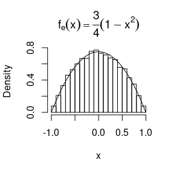

```r
set.seed(2)
n <- 10000
u <- matrix(runif(3*n,-1,1), nrow = n)
x <- numeric(n)
L <- apply(abs(u),1,which.max) == 3
coord <- 3-L
for (i in 1:n)
{
  x[i] <- u[i,coord[i]]
}
hist(x, prob = TRUE, main = expression(f[e](x)==frac(3,4)*(1-x^2)))
y <- seq(-1, 1, .01)
lines(y, (3/4)*(1-y^2))
```

#### Exercise 3.10

**Proof:** Let $X$ be the variate generated by the algorithm in Exercise 3.19, then derive the cdf of $X$, $F(x)$.
$$\begin{align*}
F(x) & =P(X\leq x) \\
& =P(U_2\leq x,|U_3|\ge|U_2|,|U_3|\ge|U_1|)+P(U_3\leq x,otherwise) \\
& =P(U_2\leq x,|U_3|\ge|U_2|,|U_3|\ge|U_1|)+P(U_3\leq x,(|U_3|<|U_2|)\cup(|U_3|<|U_1|)) \\
& =P(U_2\leq x,|U_3|\ge|U_2|,|U_3|\ge|U_1|)+P(U_3\leq x,|U_3|<|U_2|) \\
& +P(U_3\leq x,|U_3|<|U_1|)-P(U_3\leq x,|U_3|<|U_1|,|U_3|<|U_2|) \\
& +\frac{1}{8}\left[\int_{-1}^x\left(\left(\int_{-1}^{-|u_2|}+\int_{|u_2|}^1\right)\left(\int_{-|u_3|}^{|u_3|}\,du_1\right)\,du_3\right)\,du_2+2\int_{-1}^x\left(\left(\int_{-1}^{-|u_3|}+\int_{|u_3|}^1\right)\,du_2\right)\,du_3
-\int_{-1}^x\left(\left(\int_{-1}^{-|u_3|}+\int_{|u_3|}^1\right)\,du_1\right)^2\,du_3\right] \\
& =-\frac{1}{4}x^3+\frac{3}{4}x+\frac{1}{2}
\end{align*}$$
Therefore, the pdf of $X$ is
$$f(x)=\partial F(x)/\partial x=-\frac{3}{4}x^2+\frac{3}{4}=f_e(x),$$
that is, the algorithm given in Exercise 3.9 generates variates from the density $f_e$.

#### Exercise 3.13

**Solution:** Use the inverse transform method. First, derive the inverse of cdf $F(x)$ of the mixture with $r$ and $\beta$.
$$\begin{align*}
& x=F(y)=1-\left(\frac{\beta}{\beta+y}\right)^r,\quad y\ge 0 \\
& \Rightarrow \left(\frac{\beta}{\beta+y}\right)^r=1-x \\
& \Rightarrow \frac{\beta}{\beta+y}=(1-x)^{1/r} \\
& \Rightarrow y=\beta(1-x)^{-1/r}-\beta \\
& \Rightarrow F^{-1}(x)=\beta(1-x)^{-1/r}-\beta,\quad 0\leq x\leq 1
\end{align*}$$
The algorithm steps for inverse transform method are as follows: $(r=4,\beta=2,n=1000)$
**Step1:** Generate $u_i∼U[0,1],\,i=1,2,..,n$;
**Step2:** Return $X_i:=F^{-1}(u_i)=2(1-u_i)^{-1/4}-2,\,i=1,2,..,n$.

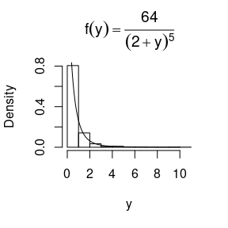

```r
set.seed(4)
r <- 4
beta <- 2
n <- 1000
u <- runif(n)
y <- beta*(1-u)^(-1/r) - beta
hist(y, prob = TRUE, main = expression(f(y)==frac(64,(2+y)^5)))
x <- seq(0, 10, .01)
lines(x, 64/((2+x)^5))
```

## Question

Exercises 5.1, 5.7 and 5.11 (pages 149-151, Statistical Computating with R).

## Answer

#### Exercise 5.1

**Solution:** First, we have
$$\theta=\int_0^{\pi/3}\sin t\,dt=\int_0^{\pi/3}[(\pi/3)\sin t]\times (3/\pi)\,dt=E[(\pi/3)\sin X]=(\pi/3)E(\sin X),$$
where $X\sim U[0,\pi/3]$.
Therefore, an algorithm by Monte Carlo method is as follow:
**Step1:** Generate $n$ random variates $U_i\sim U[0,1],i=1,2,...,n$;
**Step2:** Let $X_i=(\pi/3)U_i,i=1,2,...,n$;
**Step3:** Return $\hat\theta=\frac{\pi}{3n}\sum\limits_{i=1}^{n}\sin X_i$.

```r
set.seed(1)
n <- 10000
u <- runif(n)
x <- (pi/3)*u
theta_ <- (pi/3)*mean(sin(x))
theta <- 1 - cos(pi/3)
```

However, the exact value of the intergral is
$$\theta=\int_0^{\pi/3}\sin t\,dt=-\cos t\bigg|_0^{\pi/3}=\cos(0)-\cos(\pi/3)=1-0.5=0.5,$$
and the estimate is $\hat\theta=$ 0.4997336.

### Exercise 5.7

**solution:** First, we have
$$\theta=\int_0^1e^x\,dx=\int_0^1e^x\times 1\,dx=E(e^X),$$
where $X\sim U[0,1]$. Therefore, an algorithm by simple Monte Carlo method is as follow:
**Step1:** Generate $n$ random variates $X_i\sim U[0,1],i=1,2,...,n$;
**Step2:** Return $\hat\theta_1=\frac{1}{n}\sum\limits_{i=1}^{n}e^{X_i}$.
On the other hand, an algorithm by antithetic variate approach is as follow: **Step1’:** Generate $n$ random variates $X_i\sim U[0,1],i=1,2,...,n$;
**Step2’:** Return $\hat\theta_2=\frac{1}{n}\sum\limits_{i=1}^{n/2}(e^{X_i}+e^{1-X_i})$.

```r
set.seed(2)
n <- 10000
x1 <- runif(n)
theta_1 <- mean(exp(x1))
x2 <- runif(n/2)
theta_2 <- mean(exp(x2)+exp(1-x2))/2
m <- 1000
MC1 <- MC2 <- numeric(m)
for (i in 1:m)
{
  x1 <- runif(n)
  x2 <- runif(n/2)
  MC1[i] <- mean(exp(x1))
  MC2[i] <- mean(exp(x2)+exp(1-x2))/2
}
var1 <- var(MC1)
var2 <- var(MC2)
theta <- exp(1)-1
```

However, the exact value of the intergral is
$$\theta=\int_0^1e^x\,dx=e^x\bigg|_0^1=e-1=1.718282,$$
and the estimates by simple Monte Carlo method and by antithetic variate approach are $\hat\theta_1=$ 1.7245647 and $\hat\theta_2=$ 1.7194901, respectively.
Futhermore, the empirical variance of the estimates by simple Monte Carlo method and by antithetic variate approach are $var(\hat\theta_1)=$ 2.348050410^{-5} and $var(\hat\theta_2)=$ 7.947856410^{-7}, respectively. Then the antithetic variate approach achieved approximately 0.9661513 reduction in variance.

## Exercise 5.11

**solution:** Obviously, the variance of $\hat\theta_c=c\hat\theta_1+(1-c)\hat\theta_2$ is
$$\begin{align*}
var(\hat\theta_c) & =var(c\hat\theta_1+(1-c)\hat\theta_2) \\
& =c^2var(\hat\theta_1)+(1-c)^2var(\hat\theta_2)+2c(1-c)cov(\hat\theta_1,\hat\theta_2) \\
& =[var(\hat\theta_1)+var(\hat\theta_2)-2cov(\hat\theta_1,\hat\theta_2)]c^2+2[cov(\hat\theta_1,\hat\theta_2)-var(\hat\theta_2)]c+var(\hat\theta_2).
\end{align*}$$
Derivate $var(\hat\theta_c)$ respect to $c$ and make it equal to 0, we have
$$\begin{align*}
& \frac{\partial var(\hat\theta_c)}{\partial c}=2[var(\hat\theta_1)+var(\hat\theta_2)-2cov(\hat\theta_1,\hat\theta_2)]c+2[cov(\hat\theta_1,\hat\theta_2)-var(\hat\theta_2)] \\
& \Rightarrow c* = \frac{var(\hat\theta_2)-cov(\hat\theta_1,\hat\theta_2)}{var(\hat\theta_1)+var(\hat\theta_2)-2cov(\hat\theta_1,\hat\theta_2)}=\frac{var(\hat\theta_2)-cov(\hat\theta_1,\hat\theta_2)}{var(\hat\theta_1-\hat\theta_2)}.
\end{align*}$$

## Question

Exercises 5.13, 5.15, 6.4 and 6.5 (page 151 and 180, Statistical Computating with R).

## Answer

#### Exercise 5.13

**Solution:** First, $g(x)=\frac{x^2}{\sqrt{2\pi}}e^{-x^2/2},x>1$, the two importance functions I founed are
$$f_1(x)=\frac{2}{\sqrt{2\pi}}e^{-x^2/2},x>1,$$
and
$$f_2(x)=\frac{1}{\sqrt{2\pi}}e^{-x/2},x>1.$$
From the plot below, we can see that the two importance functions are actually “close” to $g(x)$.

[figure not shown]

```r
x <- seq(1,5,0.01)
g <- function(x) {x^2*exp(-x^2/2)/sqrt(2*pi)}
f1 <- function(x) {2*exp(-x^2/2)/sqrt(2*pi)}
f2 <- function(x) {exp(-x/2)/sqrt(2*pi)}
gs <- c(expression(g(x)==x^2*e^{(-x^2/2)}/sqrt(2*pi)),
        expression(f[1](x)==2*e^{(-x^2/2)}/sqrt(2*pi)),
        expression(f[2](x)==e^{(-x/2)}/sqrt(2*pi)))
plot(x, g(x), type = "l", ylab = "")
lines(x, f1(x), col = "red", lty = 2)
lines(x, f2(x), col = "blue", lty = 3)
legend("topright", legend = gs,
           lty = 1:3, inset = 0.02, col = 1:3)
```

Let
$$\theta=\int_1^\infty g(x)\,dx=\frac{x^2}{\sqrt{2\pi}}e^{-x^2/2}\,dx,$$
then the estimates by importance sampling with the two different importance functions are
$$\hat\theta_1=\frac{1}{n}\sum\limits_{i=1}^n\frac{g(X_i)}{f_1(X_i)}=\frac{1}{n}\sum\limits_{i=1}^n\frac{X_i
^2}{2},$$
where $X_i$ has pdf $f_1(x)=\frac{2}{\sqrt{2\pi}}e^{-x^2/2},x>1$,
$$\hat\theta_2=\frac{1}{n}\sum\limits_{i=1}^n\frac{g(X_i)}{f_2(X_i)}=\frac{1}{n}\sum\limits_{i=1}^n(X_i^2e^{-(X_i^2-X_i)/2}),$$
where $X_i$ has pdf $f_1(x)=\frac{1}{\sqrt{2\pi}}e^{-x/2},x>1$.
However, the variance of these two estimates are
$$Var(\hat\theta_1)=\frac{1}{n}Var\left(\frac{g(X)}{f_1(X)}\right)=\frac{1}{n}\left\{\int_1^\infty \left[\frac{g(x)}{f_1(x)}\right]^2f_1(x)\,dx-\theta^2\right\}=\frac{1}{n}\left\{\int_1^\infty \frac{x^4}{2\sqrt{2\pi}}e^{-x^2/2}\,dx-\theta^2\right\},$$
and
$$Var(\hat\theta_2)=\frac{1}{n}Var\left(\frac{g(X)}{f_2(X)}\right)=\frac{1}{n}\left\{\int_1^\infty \left[\frac{g(x)}{f_2(x)}\right]^2f_2(x)\,dx-\theta^2\right\}=\frac{1}{n}\left\{\int_1^\infty \frac{x^4}{\sqrt{2\pi}}e^{-x^2+x/2}\,dx-\theta^2\right\}.$$
Hence, $Var(\hat\theta_1)<Var(\hat\theta_2)$.

**Solution:** Use the stratified importance sampling, and choose $f(x)=e^{-x}/(1-e^{-1}),0<x<1$ as the importance function. Divide the integral interval $(0,1)$ into five subintervals $I_j=\{x:a_{j-1}\leq x\leq a_j\}$ with endpoints $a_0=0,a_j=F^{-1}(j/5)=-\log[j(e^{-1}-1)/5+1],j=1,...,k-1$, and $a_k=1$.
Then on the $j^{th}$ subinterval variablesare generated from the pdf
$$f_j(x)=\frac{5e^{-x}}{1-e^{-1}},\,\frac{j-1}{5}<x<\frac{j}{5}.$$
To sum up, the steps of the algorithm by for this method are
**Step1:** Let $j:=1$;
**Step2:** For the $j^{th}$ subinterval, generate random variates $U_i\sim U(0,1),i=1,...,n/k$;
**Step3:** Let $X_i=-\log[(e^{-1}-1)(U_i+j-1)/5+1]$, and return $\hat\theta_k=\frac{k}{n}\sum\limits_{i=1}^{n/k}\frac{1-e^{-1}}{1+X_i^2}$;
**Step4:** if $k<5$, then go back to **Step2**, and return $\hat\theta=\frac{1}{5}\sum\limits_{j=1}^{5}\hat\theta_j$ otherwise.

```r
n <- 10000
k <- 5
N <- 100
set.seed(2)
theta_ <- numeric(k)
est <- numeric(N)
for (i in 1:N)
{
  for (j in 1:k)
 {
  u <- runif(n/k)
  x <- -log((exp(-1)-1)*(u+j-1)/5+1)
  theta_[j] <- mean((1-exp(-1))/(1+x^2))
 }
 est[i] = mean(theta_)
}
theta <- mean(est)
sd <- sd(est)
```

#### Exercise 6.4

Assume that $X$ is a random variable following lognormal distribution, then $\log X\sim N(\mu,\sigma^2)$. We have
$$\frac{\frac{1}{n}\sum\limits_{i=1}^n\log X_i-\mu}{S/\sqrt n}\sim t(n-1).$$
Then the confidence interval of $\mu$ is
$$\frac{1}{n}\sum\limits_{i=1}^n\log X_i\pm t_{\alpha/2}S/\sqrt n,$$
where $t_{\alpha/2}$ is the $\alpha/2$ upper quantile of t-distribution, and $S$ is the sample variance of $\log X$. Then $\widehat{CLC}=\frac{1}{n}\sum\limits_{i=1}^n\log X_i- t_{\alpha/2}S/\sqrt n$ and $\widehat{ULC}=\frac{1}{n}\sum\limits_{i=1}^n\log X_i+ t_{\alpha/2}S/\sqrt n$.
The EPC is
$$\frac{1}{N}\sum\limits_{i=1}^NI\{\widehat{CLC}_i\leq\mu\leq\widehat{ULC}_i\}.$$
Now generate lognormal distribution variates $X_1,..,X_n$ with $\mu=0,\sigma^2=1$.

```r
set.seed(3)
n <- 20
mu <- 0
sigma <- 1
N <- 1000
LCL <- UCL <- numeric(N)
for (i in 1:N)
{
  x <- rlnorm(n, 0, 1)
  LCL[i] <- mean(log(x)) - qt(0.975,n-1)*sd(log(x))/sqrt(n)
  UCL[i] <- mean(log(x)) + qt(0.975,n-1)*sd(log(x))/sqrt(n)
}
ECP <- mean(LCL <= mu & UCL >= mu)
```

The EPC is 0.95, which actually equals $1-\alpha=0.95$.

#### Exercise 6.5

The confidence interval of the mean of normal variable is
$$\bar X\pm t_{\alpha/2}S/\sqrt n,$$
where $t_{\alpha/2}$ is the $\alpha/2$ upper quantile of t-distribution, and $S$ is the sample variance of $X$. Then $\widehat{CLC}=\bar X- t_{\alpha/2}S/\sqrt n$ and $\widehat{ULC}=\bar X+t_{\alpha/2}S/\sqrt n$.
The EPC is
$$\frac{1}{N}\sum\limits_{i=1}^NI\{\widehat{CLC}_i\leq\mu\leq\widehat{ULC}_i\}.$$

```r
set.seed(4)
n <- 20
mu <- 2
N <- 1000
LCL <- UCL <- numeric(N)
for (i in 1:N)
{
  x <- rchisq(n, 2)
  LCL[i] <- mean(x) - qt(0.975,n-1)*sd(x)/sqrt(n)
  UCL[i] <- mean(x) + qt(0.975,n-1)*sd(x)/sqrt(n)
}
ECP <- mean(LCL <= mu & UCL >= mu)
```

The EPC is 0.906 when $X\sim\chi^2(2)$, which is much lower than $1-\alpha=0.95$.

## Question

Exercises 6.7, 6.8, 6.C and a discussion (page 180-182, Statistical Computating with R).

## Answer

#### Exercise 6.7

**Solution:** The hypotheses of Skewness test of normality are
$$H_0:\sqrt{\beta_1}=0;\quad H_1:\sqrt{\beta_1}\ne0.$$
And the test statistic is
$$\begin{equation}
\sqrt{b_1}=\frac{\frac{1}{n}\sum_{i=1}^n(X_i-\bar X)^3}{(\frac{1}{n}\sum_{i=1}^n(X_i-\bar X)^2)^{3/2}},
\end{equation}$$
which is asymptotically normal with mean 0 and variance $\frac{6(n-2)}{(n+1)(n+3)}$, and large if the distribution of $X$ is unnormal.

Then the **Monte Carlo experiment to estimate power of a test against symmetric Beta(a,a) distributions (t(v) distributions)** is

1.Select the particular values of the parameter a of $Beta(a,a)$ ($v$ of $t(v)$).

2.For each replicate, indexed by $j=1,...,m$:

(a)Generate the $j^{th}$ random sample $x_1^{(j)},...,x_n^{(j)}$ from $Beta(a,a)$ (from $t(v)$).

(b)Compute the test statistic $\sqrt{b_1}$ from the $j^{th}$ sample.

(c)Record the test decision: set $I_j=1$ if $H_0$ is rejected at significance level $\alpha$, and otherwise set $I_j=0$.

3.Compute the proportion of significant test $\hat\pi(\theta_1)=\frac{1}{m}\sum_{j=1}^mI_j$.

```r
set.seed(1)
n <- 100
m <- 10000
a <- c(1, 5, 20) # alternatives
v <- c(1, 10, 100) # alternatives
alpha <- 0.05
cv <- qnorm(1-alpha/2, 0, sqrt(6*(n-2)/((n+1)*(n+3))))
sk <- function(x)
{
  x_ <- mean(x)
  m3 <- mean((x-x_)^3)
  m2 <- mean((x-x_)^2)
  m3/m2^1.5
}
power_beta <- power_t <- numeric(length(a))
for (i in 1:length(a))
{
  # Beta(a,a)
  sktests_beta <- replicate(m, expr = {
    x <- rbeta(n, a[i], a[i])
    as.integer(abs(sk(x)) >= cv)
  })
  power_beta[i] <- mean(sktests_beta)
  # t(v)
  sktests_t <- replicate(m, expr = {
    x <- rt(n, v[i])
    as.integer(abs(sk(x)) >= cv)
  })
  power_t[i] <- mean(sktests_t)
}
```

Choose the sets of $a=\{1,5,20\}$ and $v=\{1,10,100\}$, and the results are as follows: |$Beta(a,a)$|Power|$t(v)$|Power| |-|-|-|-| |$a=1$|0.0019|$v=1$|0.9552| |$a=5$|0.0098|$v=10$|0.2002| |$a=20$|0.0319|$v=100$|0.0621|

#### Exercise 6.8

**Solution:** The **Monte Carlo experiment to estimate power of Count Five tset (and $F$-tset) against a fixed alternative** is

1.Select the sample sizes represents small, medium and large.

2.For each replicate, indexed by $j=1,...,m$:

(a)Generate the $j^{th}$ random sample $x_1^{(j)},...,x_n^{(j)},y_1^{(j)},...,y_n^{(j)}$ from $N(0,1)$ and $N(0,1.5^2)$.

(b)Compute the test statistic $\max\{\sum_{i=1}^n(x_i^{(j)}>\max(y^{(j)}))+\sum_{i=1}^n(x_i^{(j)}<\min(y^{(j)})),\sum_{i=1}^n(y_i^{(j)}>\max(x^{(j)}))+\sum_{i=1}^n(y_i^{(j)}<\min(x^{(j)}))\}$ (and $S_x^2/S_y^2$) from the $j^{th}$ sample.

(c)Record the test decision: set $I_j=1$ if $H_0$ is rejected at significance level $\alpha$, and otherwise set $I_j=0$.

3.Compute the proportion of significant test $\hat\pi(\theta_1)=\frac{1}{m}\sum_{j=1}^mI_j$.

```r
set.seed(2)
sigma_1 <- 1
sigma_2 <- 1.5
n <- c(10, 50, 100)
alpha <- 0.055
m <- 10000
count5test <- function(x, y)
{
  X <- x - mean(x)
  Y <- y - mean(y)
  outx <- sum(X > max(Y)) + sum(X < min(Y))
  outy <- sum(Y > max(X)) + sum(Y < min(X))
  as.integer(max(c(outx, outy)) > 5)
}
power_5 <- power_F <- numeric(length(n))
for (i in 1:length(n))
{
  power_5[i] <- mean(replicate(m, expr = {
  x <- rnorm(n[i], 0, sigma_1)
  y <- rnorm(n[i], 0, sigma_2)
  count5test(x,y)
}))
  pvalues <- replicate(m, expr = {
  x <- rnorm(n[i], 0, sigma_1)
  y <- rnorm(n[i], 0, sigma_2)
  Ftest <- var.test(x, y)
  Ftest$p.value
})
  power_F[i] <- mean(pvalues <= alpha)
}
```

Choose the set of $n=\{10,50,100\}$, and the results are as follows: |Sample size|Count Five test|$F$-test| |-|-|-| |$n=10$|0.1051|0.2122| |$n=50$|0.654|0.8105| |$n=100$|0.8433|0.9832| We can see that the powers of $F$-test are higher than those of Count Five test, which indicates that the $F$-test is not applicable for non-normal distribution.

#### Exercise 6.C

The hypotheses of Mardia’s multivariate Skewness test of normality are
$$H_0:\sqrt{\beta_{1,d}}=0;\quad H_1:\sqrt{\beta_{1,d}}\ne0.$$
And the test statistic is
$$\begin{equation}
\sqrt{b_{1,d}}=\frac{1}{n^2}\sum_{i,j=1}^n((X_i-\bar X)^T\hat\Sigma^{-1}(X_j-\bar X))^3
\end{equation}$$
which is asymptotically chisquared with $d(d+1)(d+2)/6$ degrees of freedom, and large if the distribution of $X$ is unnormal.

Choose the multivariate normal distribution is that with parameter $\mu=(0,0)^T$ and $\Sigma=\left(\begin{smallmatrix} 1 & 0.5 \\ 0.5 & 1 \end{smallmatrix}\right)$.

```r
library(MASS)
set.seed(3)
# Example 6.8
n <- c(10, 20, 30, 50, 100, 500)
mu0 <- rep(0,2)
Sigma <- matrix(c(1,.5,.5,1), nrow = 2)
d <- length(mu0)
cv <- qchisq(c(1-.975,.975), d*(d+1)*(d+2)/6)
multisk <- function(x)
{
  X <- as.matrix(x)
  n <- dim(X)[1]
  Sigma <- (n-1)*var(X)/n
  S_1 <- solve(Sigma)
  X_ <- as.matrix(apply(X, 2, mean))
  b <- 0
  for (i in 1:n)
  {
    for (j in 1:n)
    {
      b <- b + (t(X[i,]-X_)%*%S_1%*%(X[j,]-X_))^3
    }
  }
  b/n^2
}
p_reject <- numeric(length(n))
m <- 1000
for (i in 1:length(n))
{
  p_reject[i] <- mean(replicate(m, expr = {
    x <- mvrnorm(n = n[i], mu0, Sigma)
    sk <- multisk(x)
    as.integer(n[i]*sk/6 < cv[1] | n[i]*sk/6 > cv[2])
  }))
}
```

Then estimate the power of the Mardia’s multivariate Skewness test of normality against a contaminated normal alternative:
$$(1-\epsilon)N\left(\left(\begin{smallmatrix}0\\0\end{smallmatrix}\right),\left(\begin{smallmatrix}1 & 0.5\\0.5 & 1\end{smallmatrix}\right)\right)+\epsilon N\left(\left(\begin{smallmatrix}0\\0\end{smallmatrix}\right),\left(\begin{smallmatrix}100 & 0.5\\0.5 & 100\end{smallmatrix}\right)\right),\quad0\leq\epsilon\leq1.$$

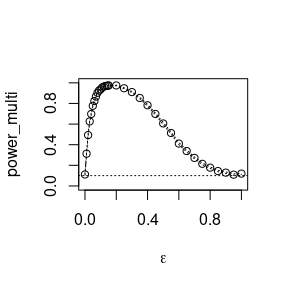

```r
# Example 6.10
alpha <- .1
n <- 30
m <- 2500
mu1 <- mu2 <- rep(0,2)
Sigma1 <- matrix(c(1,.5,.5,1), nrow = 2)
Sigma2 <- matrix(c(100,.5,.5,100), nrow = 2)
d <- length(mu0)
epsilon <- c(seq(0, .15, .01), seq(.15, 1, .05))
N <- length(epsilon)
power_multi <- numeric(N)
cv <- qchisq(c(alpha/2,1-alpha/2), d*(d+1)*(d+2)/6)
for (i in 1:N)
{
  e <- epsilon[i]
  power_multi[i] <- mean(replicate(m, expr = {
    index <- sample(c(1,2), replace = T, size = n, prob = c(1-e,e))
    x <- matrix(nrow = n, ncol = d)
    for (j in 1:n)
    {
      if (index[j] == 1)
        x[j,] <- mvrnorm(1, mu1, Sigma1)
      else
        x[j,] <- mvrnorm(1, mu2, Sigma2)
    }
    sk <- multisk(x)
    as.integer(n*sk/6 < cv[1] | n*sk/6 > cv[2])
  }))
}
plot(epsilon, power_multi, type = "b",
     xlab = bquote(epsilon), ylim = c(0,1))
abline(h = alpha, lty = 3)
se <- sqrt(power_multi*(1-power_multi)/m)
lines(epsilon, power_multi+se, lty = 3)
lines(epsilon, power_multi-se, lty = 3)
```

The empirical power curve is shown above. Note that the power curve crosses the horizontal line corresponding to $\alpha=0.10$ at both endpoints, $\epsilon=0$ and $\epsilon =1$ where the alternative is normally distributed. For $0\leq\epsilon\leq1$ the empirical power of the test is greater than 0.10 and highest when $\epsilon$ is about 0.15.

#### Discussion

First we can not consider the two powers are different directly through inexact equality.

(a)The corresponding hypothesis test problem is whether the two powers obtained by two different methods are different, that is , the hypothesess are:
$$H_0:pw_1=pw_2;\quad H_1:pw_1\ne pw_2.$$

(b)We should use Z-test, since the empirical power is a proportion that reject null hypothesis.

(c)Since the test statistic is
$$Z=\frac{pw_1-pw_2}{\sqrt{\frac{pw_1(1-pw_1)}{n_1}+\frac{pw_2(1-pw_2)}{n_2}}},$$
We need the sample sizes of two methods and the two estimated powers.

## Question

Exercises 7.1, 7.5, 7.8 and 7.11 (page 212-213, Statistical Computating with R).

## Answer

#### Exercise 7.1

**Solution:** The jackknife estimatie of the bias and the standard error are
$$\widehat{bias}_J=(n-1)(\overline{\bar X^*}_{(\cdot)}-\bar X),$$
and
$$\hat{se}_J=\sqrt{\frac{n-1}{n}\sum\limits_{i=1}^n(\bar X_{(i)}-\overline{\bar X^*}_{(\cdot)})^2}.$$

```r
data(law, package = "bootstrap")
n <- nrow(law)
cor_ <- cor(law$LSAT, law$GPA)
cor_jack <- numeric(n)
for (i in 1:n)
{
  cor_jack[i] <- cor(law$LSAT[-i], law$GPA[-i])
}
bias_jack <- (n-1) * (mean(cor_jack)-cor_)
se_jack <- sd(cor_jack) / sqrt(n) * (n-1)
```

By calculation, the jackknife estimatie of the bias and the standard error are -0.0064736 and 0.1425186 respectively.

#### Exercise 7.5

**Solution:** The standard normal bootstrap CI is
$$(\bar X-z_{\alpha/2}\hat{se}(\bar X),\bar X+z_{\alpha/2}\hat{se}(\bar X))$$
, the basic bootstrap CI is
$$(2\bar X-\bar X^*_{1-\alpha/2},2\bar X-\bar X^*_{\alpha/2})$$
, the percentile bootstrap CI is
$$(\bar X^*_{1-\alpha/2},\bar X^*_{\alpha/2})$$
, and the BCa is
$$(\bar X^*_{\alpha1},\bar X^*_{\alpha2}),$$
where
$$\alpha_1=\Phi\left(\hat z_0+\frac{\hat z_0+z_{\alpha/2}}{1-\hat a(\hat z_0+z_{\alpha/2})}\right),$$
$$\alpha_2=\Phi\left(\hat z_0+\frac{\hat z_0+z_{1-\alpha/2}}{1-\hat a(\hat z_0+z_{1-\alpha/2})}\right).$$
$$\hat z_0=\Phi^{-1}\left(\frac{1}{B}\sum\limits_{b=1}^B I(\bar X^{(b)}<\bar X)\right),$$
$$\hat a=\frac{\sum_{i=1}^n(\bar X_{(.)}-\bar X_{(i)})^3}{6\left[\sum\limits_{i=1}^n(\bar X_{(.)}-\bar X_{(i)})^2\right]^{3/2}}.$$

```r
library(boot)
data(aircondit, package = "boot")
set.seed(15798)
B <- 1000
boot_mean <- function(x, i) mean(x[i])
m <- boot(data = aircondit$hours, statistic = boot_mean, R = B)
CI <- boot.ci(m, type = c("norm", "basic", "perc", "bca"))
print(CI)
```

```
## BOOTSTRAP CONFIDENCE INTERVAL CALCULATIONS
## Based on 1000 bootstrap replicates
##
## CALL :
## boot.ci(boot.out = m, type = c("norm", "basic", "perc", "bca"))
##
## Intervals :
## Level      Normal              Basic
## 95%   ( 40.9, 178.6 )   ( 32.5, 168.3 )
##
## Level     Percentile            BCa
## 95%   ( 47.8, 183.7 )   ( 59.3, 216.3 )
## Calculations and Intervals on Original Scale
## Some BCa intervals may be unstable
```

The intervals are all different, since they hey have different structures. The standard normal bootstrap CI is based on asymptotic normality, the basic bootstrap CI is based on the large sample property, the percentile bootstrap CI is by assuming $\bar X^*|X_1,...,X_n$ and $\bar X$ have approximately the same distribution, and the BCa is a bias-corrected and accelerated CI for percentile bootstrap CI.

#### Exercise 7.8

**Solution:** The jackknife estimatie of the bias and the standard error are similar with Exercise 7.1.

```r
set.seed(54964)
data(scor, package = "bootstrap")
B <- 2000
n <- nrow(scor)
Sigma_ <- var(scor)
eigen_ <- eigen(Sigma_, symmetric = T)
theta_ <- eigen_$values[1] / sum(eigen_$values)
Jackknife <- function(data)
{
  theta_jack <- numeric(n)
  for (i in 1:n)
  {
    Sigma_jack <- var(scor[-i,])
    eigen_jack <- eigen(Sigma_jack, symmetric = T)
    theta_jack[i] <- eigen_jack$values[1] / sum(eigen_jack$values)
  }
  theta_jack
}
theta_jack <- Jackknife(data = scor)
bias_jack <- (n-1) * (mean(theta_jack)-theta_)
sd_jack <- sqrt((n-1) * mean((theta_jack-mean(theta_jack))^2))
```

By calculation, the jackknife estimatie of the bias and the standard error are 0.0010691 and 0.0495523 respectively.

#### Exercise 7.11

**Solution:** **Procedure to estimate prediction error by leave-two-out cross validation**

1.For $k=1,...,n-1,\,l=k+1,...,n$, let observation$(x_k,y_k),(x_l,y_l)$ be the test sample and use the remaining observations to fit the model.

(a)Fit the model(s) using only the $n-2$ observations in the training set, $(x_i,y_i),i\ne k,l$.

(b)Compute the predicted response $\hat y_j=\hat\beta_0+\hat\beta_1x_j,j=k,l$ for the test sample.

(c)Compute the squared prediction error $e_{k,l}^2=(y_k-\hat y_k)^2+(y_l-\hat y_l)^2$

2.Estimate the mean of the squared prediction errors $\hat\sigma_\epsilon^2=\frac{2}{n(n-1)}\sum_{k=1}^{n-1}\sum_{l=k+1}^ne_{k,l}^2$.

```r
library(lattice)
library(DAAG)
data(ironslag)
n <- length(ironslag$magnetic)
e1 <- e2 <- e3 <- e4 <- matrix(nrow = n*(n-1)/2, ncol = 2)
flag <- 1
for (i in 1:(n-1))
{
  for (j in (i+1):n)
  {
    y <- ironslag$magnetic[-c(i,j)]
    x <- ironslag$chemical[-c(i,j)]
    lm1 <- lm(y ~ x, data = ironslag)
    y_ <- predict(lm1, newdata = data.frame(x = ironslag$chemical[c(i,j)]))
    e1[flag,] <- ironslag$magnetic[c(i,j)] - y_

    lm2 <- lm(y ~ x + I(x^2), data = ironslag)
    y_ <- predict(lm2, newdata = data.frame(x = ironslag$chemical[c(i,j)]))
    e2[flag,] <- ironslag$magnetic[c(i,j)] - y_

    lm3 <- lm(log(y) ~ x, data = ironslag)
    y_ <- predict(lm3, newdata = data.frame(x = ironslag$chemical[c(i,j)]))
    e3[flag,] <- ironslag$magnetic[c(i,j)] - y_

    lm4 <- lm(log(y) ~ log(x), data = ironslag)
    y_ <- predict(lm4, newdata = data.frame(x = ironslag$chemical[c(i,j)]))
    e4[flag,] <- ironslag$magnetic[c(i,j)] - y_

    flag <- flag + 1
  }
}
cat("model1 =", mean(apply(e1^2, 1, sum)),
"model2 =", mean(apply(e2^2, 1, sum)),
"model3 =", mean(apply(e3^2, 1, sum)),
"model4 =", mean(apply(e4^2, 1, sum))
)
```

```
## model1 = 39.14455 model2 = 35.74037 model3 = 705.4365 model4 = 705.7991
```

From the result, we can see the prediction error of model2 is the lowest, so model2 is the best.

## Question

Exercises 8.3 and experiments(page 243, Statistical Computating with R).

## Answer

#### Exercise 8.3

**Solution:**

**Approximate permutation test procedure**

1.Compute the observed test statistic $\hat\theta(X,Y)=\hat\theta(Z,\nu)=\max(c(outx,outy))$.

2.For each replicate, indexed $b=1,...,B$:

(a)Generate a random permutation $\pi_b=\pi(\nu)$.

(b)Compute the statistic $\hat\theta^{(b)}=\hat\theta^*(Z,\pi_b)$.

3.If large values of $\hat\theta$ support the alternative, compute the ASL (the empirical p-value) by
$$\hat p=\frac{1+\sum_{b=1}^BI(\hat\theta^{(b)})\ge\hat\theta}{B+1}.$$
For a lower-tail or two-tail test test test $\hat p$is computed in a similar way.

4.Reject $H_0$at significant level $\alpha$ if $\hat p\le\alpha$.

```r
counttest <- function(x, y)
{
  X <- x - mean(x)
  Y <- y - mean(y)
  outx <- sum(X > max(Y)) + sum(X < min(Y))
  outy <- sum(Y > max(X)) + sum(Y < min(X))
  max(c(outx, outy))
}

n1 <- 20
n2 <- 30
mu1 <- 1
mu2 <- 0
sigma1 <- sigma2 <- 1
B <- 1000
m <- 100
reject <- 0
for (i in 1:m)
{
  x1 <- rnorm(n1, mu1, sigma1)
  x2 <- rnorm(n2, mu2, sigma2)
  z <- c(x1, x2)
  t0 <- counttest(x1, x2)
  t <- replicate(B, expr = {
    k <- sample(1:length(z), size = length(x1), replace = F)
    x <- z[k]
    y <- z[-k]
    counttest(x, y)
  })
  p <- mean(c(t0, t) >= t0)
  reject <- reject + (p < .05)
}
reject / m
```

```
## [1] 0.02
```

The output of reject proportion is close to $\alpha=0.05$, which indicates that the new method based on permutation test is applicable.

#### Experiment

```r
library(RANN)
library(boot)
library(energy)
library(Ball)
Tn <- function(z, ix, sizes,k)
{
  n1 <- sizes[1]; n2 <- sizes[2]; n <- n1 + n2
  if(is.vector(z)) z <- data.frame(z,0);
  z <- z[ix, ];
  NN <- nn2(data = z, k = k+1)
  block1 <- NN$nn.idx[1:n1,-1]
  block2 <- NN$nn.idx[(n1+1):n,-1]
  i1 <- sum(block1 < n1 + .5); i2 <- sum(block2 > n1+.5)
  (i1 + i2) / (k * n)
}

# Unequal variances and equal expectations
n1 <- 50
n2 <- 50
mu1 <- 0
mu2 <- 0
sigma1 <- 1
sigma2 <- 4
m <- 1e3
k <- 3
R <- 999
n <- n1 + n2
N = c(n1,n2)
eqdist.nn <- function(z,sizes,k)
{
  boot.obj <- boot(data = z, statistic = Tn, R = R, sim = "permutation", sizes = sizes, k = k)
  ts <- c(boot.obj$t0, boot.obj$t)
  p.value <- mean(ts >= ts[1])
  list(statistic = ts[1], p.value = p.value)
}
p.values <- matrix(NA, m ,3)
for(i in 1:m)
{
  x <- matrix(rnorm(n1, mu1, sigma1), ncol = 1)
  y <- matrix(rnorm(n2, mu2, sigma2), ncol = 1)
  z <- rbind(x,y)
  p.values[i,1] <- eqdist.nn(z, N, k)$p.value
  p.values[i,2] <- eqdist.etest(z, sizes = N, R = R)$p.value
  p.values[i,3] <- bd.test(x = x, y = y, R = 999, seed = i*1165)$p.va
}
alpha <- .05;
power1 <- colMeans(p.values < alpha)
```

```r
# Unequal variances and unequal expectations
n1 <- 50
n2 <- 50
mu1 <- 0
mu2 <- 5
sigma1 <- 1
sigma2 <- 4
m <- 1e3
k <- 3
R <- 999
n <- n1 + n2
N = c(n1,n2)
eqdist.nn <- function(z,sizes,k)
{
  boot.obj <- boot(data = z, statistic = Tn, R = R, sim = "permutation", sizes = sizes, k = k)
  ts <- c(boot.obj$t0, boot.obj$t)
  p.value <- mean(ts >= ts[1])
  list(statistic = ts[1], p.value = p.value)
}
p.values <- matrix(NA, m ,3)
for(i in 1:m)
{
  x <- matrix(rnorm(n1, mu1, sigma1), ncol = 1)
  y <- matrix(rnorm(n2, mu2, sigma2), ncol = 1)
  z <- rbind(x,y)
  p.values[i,1] <- eqdist.nn(z, N, k)$p.value
  p.values[i,2] <- eqdist.etest(z, sizes = N, R = R)$p.value
  p.values[i,3] <- bd.test(x = x, y = y, R = 999, seed = i*7864)$p.va
}
alpha <- .05;
power2 <- colMeans(p.values < alpha)
```

```r
# Non-normal distributions
n1 <- 50
n2 <- 50
mu1 <- 0
mu2 <- 5
sigma1 <- 1
sigma2 <- 4
m <- 1e3
k <- 3
R <- 999
n <- n1 + n2
N = c(n1,n2)
eqdist.nn <- function(z,sizes,k)
{
  boot.obj <- boot(data = z, statistic = Tn, R = R, sim = "permutation", sizes = sizes, k = k)
  ts <- c(boot.obj$t0, boot.obj$t)
  p.value <- mean(ts >= ts[1])
  list(statistic = ts[1], p.value = p.value)
}
p.values <- matrix(NA, m ,3)
for(i in 1:m)
{
  x <- matrix(rt(n1, df = 1), ncol = 1)
  y <- matrix(c(rnorm(n2/2, mu1, sigma1), rnorm(n2/2, mu2, sigma2)), ncol = 1)
  z <- rbind(x,y)
  p.values[i,1] <- eqdist.nn(z, N, k)$p.value
  p.values[i,2] <- eqdist.etest(z, sizes = N, R = R)$p.value
  p.values[i,3] <- bd.test(x = x, y = y, R = 999, seed = i*94654)$p.va
}
alpha <- .05;
power3 <- colMeans(p.values < alpha)
```

```r
# Unbalanced samples
n1 <- 50
n2 <- 5
mu1 <- 0
mu2 <- 5
sigma1 <- 1
sigma2 <- 4
m <- 1e3
k <- 3
R <- 999
n <- n1 + n2
N = c(n1,n2)
eqdist.nn <- function(z,sizes,k)
{
  boot.obj <- boot(data = z, statistic = Tn, R = R, sim = "permutation", sizes = sizes, k = k)
  ts <- c(boot.obj$t0, boot.obj$t)
  p.value <- mean(ts >= ts[1])
  list(statistic = ts[1], p.value = p.value)
}
p.values <- matrix(NA, m ,3)
for(i in 1:m)
{
  x <- matrix(rnorm(n1, mu1, sigma1), ncol = 1)
  y <- matrix(rnorm(n2, mu2, sigma2), ncol = 1)
  z <- rbind(x,y)
  p.values[i,1] <- eqdist.nn(z, N, k)$p.value
  p.values[i,2] <- eqdist.etest(z, sizes = N, R = R)$p.value
  p.values[i,3] <- bd.test(x = x, y = y, R = 999, seed = i*78324)$p.va
}
alpha <- .05;
power4 <- colMeans(p.values < alpha)
```

The result is as follow:

| NN | Energy | Ball |
| --- | --- | --- |
| 0.999 | 1 | 1 |
| 1 | 1 | 1 |
| 0.501 | 0.943 | 0.622 |
| 0.948 | 0.995 | 0.872 |

That indicates Energy test could deal with the Non-normal distributions problem and Unbalanced samples problem. In addition, the results of three methods are similar with the Unequal variances or expectations problem.

## Question

Exercises 9.4 and 11.4 (page 277 and 353, Statistical Computating with R).

## Answer

#### Exercise 9.4

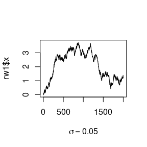

```r
rw_Metropolis <- function(sigma, x0, N)
{
  x <- numeric(N)
  x[1] <- x0
  u <- runif(N)
  k <- 0
  for (i in 2:N)
  {
    y <- rnorm(1, x[i-1], sigma)
    if (u[i] <= exp(-abs(y))/exp(-abs(x[i-1])))
      x[i] <- y
    else
    {
      x[i] <- x[i-1]
      k <- k + 1
    }
  }
  list(x = x, k = k)
}

set.seed(324)
N <- 2000
sigma <- c(.05, .5, 2, 4)
x0 <- 0
rw1 <- rw_Metropolis(sigma[1], x0, N)
rw2 <- rw_Metropolis(sigma[2], x0, N)
rw3 <- rw_Metropolis(sigma[3], x0, N)
rw4 <- rw_Metropolis(sigma[4], x0, N)
plot(1:N, rw1$x, type = "l", xlab = expression(sigma==0.05))
```

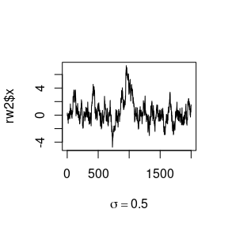

```r
plot(1:N, rw2$x, type = "l", xlab = expression(sigma==0.5))
```

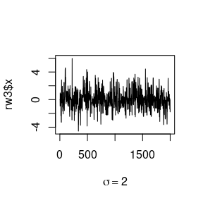

```r
plot(1:N, rw3$x, type = "l", xlab = expression(sigma==02))
```

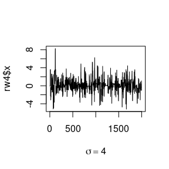

```r
plot(1:N, rw4$x, type = "l", xlab = expression(sigma==4))
```

```r
accept <- 1 - c(rw1$k, rw2$k, rw3$k, rw4$k) / N
print(accept)
```

```
## [1] 0.9815 0.8320 0.5190 0.3370
```

From the plots, we can see that the ratios $r(X_t,Y)$ with $\sigma=0.05$ tend to be large and almost every candidate point is accepted. The increments are small and the chain is almost like a true random walk. Chain 1 has not converged to the target in 2000 interations. The Chain 2 generated with $\sigma=0.5$ is converging slowly. The Chain 3 and Chain 4 are mixing well and converging to the targest distribution after a short burn-in period.

In addtion, the acceptance rates are 0.9815, 0.832, 0.519, 0.337 respectively,

## Exercise 9.4(Cont.)

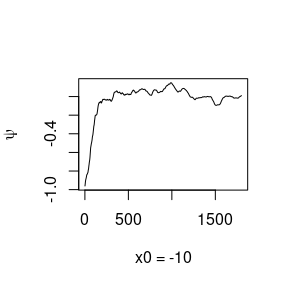

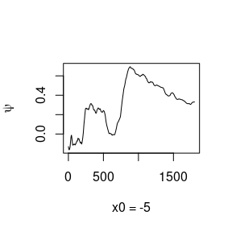

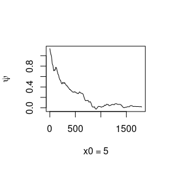

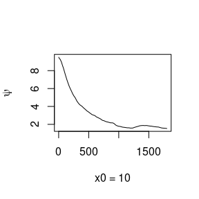

```r
GR <- function(psi)
{
  psi <- as.matrix(psi)
  n <- ncol(psi)
  k <- nrow(psi)
  m <- rowMeans(psi)
  B <- n * var(m)
  w <- apply(psi, 1, "var")
  W <- mean(w)
  v_ <- W*(n-1)/n + B/n
  r_ <- v_ / W
  r_
}

set.seed(324)
N <- 2000
burn <- 200
x0 <- c(-10, -5, 5, 10)
X <- matrix(nrow = 4, ncol = N)
for (i in 1:4)
{
  X[i,] <- rw_Metropolis(sigma[2], x0[i], N)$x
}
psi <- t(apply(X, 1, cumsum))
for (i in 1:nrow(psi))
  psi[i,] <- psi[i,] / (1:ncol(psi))
R_ <- GR(psi)
for (i in 1:4)
  plot(psi[i, (burn+1):N], type = "l", xlab = paste("x0 =", x0[i]), ylab = bquote(psi))
```

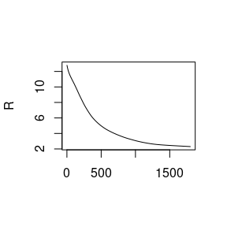

```r
r_ <- numeric(N)
for (i in (burn+1):N)
  r_[i] <- GR(psi[,1:i])
plot(r_[(burn+1):N], type = "l", xlab = "", ylab = "R")
abline(h = 1.2, lty = 2)
```

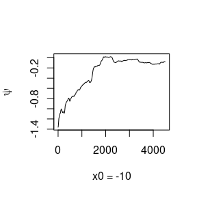

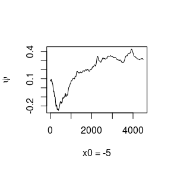

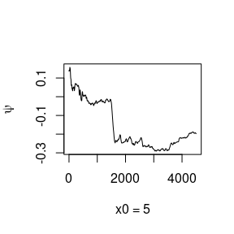

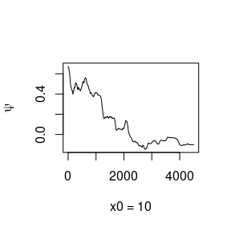

```r
N <- 5000
burn <- 500
x0 <- c(-10, -5, 5, 10)
X <- matrix(nrow = 4, ncol = N)
for (i in 1:4)
{
  X[i,] <- rw_Metropolis(sigma[2], x0[i], N)$x
}
psi <- t(apply(X, 1, cumsum))
for (i in 1:nrow(psi))
  psi[i,] <- psi[i,] / (1:ncol(psi))
for (i in 1:4)
  plot(psi[i, (burn+1):N], type = "l", xlab = paste("x0 =", x0[i]), ylab = bquote(psi))
```

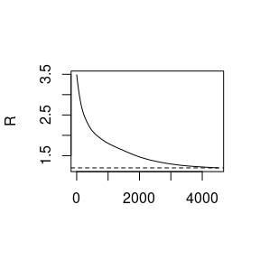

```r
r_ <- numeric(N)
for (i in (burn+1):N)
  r_[i] <- GR(psi[,1:i])
plot(r_[(burn+1):N], type = "l", xlab = "", ylab = "R")
abline(h = 1.2, lty = 2)
```

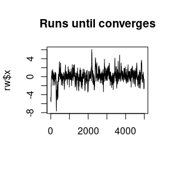

```r
index <- min(which(r_[r_ != 0] < 1.2))
rw <- rw_Metropolis(sigma[2], x0[2], index+burn)
plot(1:(index+burn), rw$x, type = "l", xlab = "", main = "Runs until converges")
```

## Exercise 11.4

```r
k <- c(4:25, 100, 500, 1000)
roots <- numeric(length(k))
for (i in 1:length(k))
{
  f <- function(a) pt(sqrt(a^2*(k[i]-1)/(k[i]-a^2)), df = k[i]-1) - pt(sqrt(a^2*k[i]/(k[i]+1-a^2)), df = k[i])
  roots[i] <- uniroot(f, c(1e-10,sqrt(k[i])-1e-10))$root
}
print(roots)
```

```
##  [1] 1.492103e+00 1.533549e+00 1.562768e+00 1.584421e+00 1.601182e+00
##  [6] 1.614517e+00 1.625356e+00 1.634398e+00 1.642026e+00 1.648543e+00
## [11] 1.654174e+00 1.659100e+00 1.663458e+00 1.667292e+00 1.670738e+00
## [16] 1.673818e+00 1.676623e+00 1.679137e+00 1.681461e+00 4.795832e+00
## [21] 4.898979e+00 5.000000e+00 1.000000e+01 2.236068e+01 1.000000e-10
```

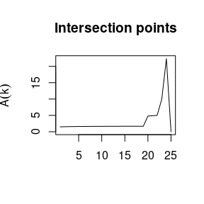

```r
plot(1:length(k), type = "l", roots, xlab = "", ylab = expression(A(k)), main = "Intersection points")
```

## Question

A-B-O blood problem, Exercises 3, 3 and 6 (page 204, 213-214, Advanced R).

## Answer

#### A-B-O blood problem

The likelihood for full data is
$$L(p,q|n_{AA},n_{AO},n_{BB},n_{BO},n_{OO},n_{AB})=(p^2)^{n_{AA}}(2p(1-p-q))^{n_{AO}}(q^2)^{n_{BB}}(2q(1-p-q))^{n_{BO}}(1-p-q)^{2n_{OO}}(2pq)^{n_{AB}},$$
and the corresponding log-likelihood is
$$\begin{align*}
& l(p,q|n_{AA},n_{AO},n_{BB},n_{BO},n_{OO},n_{AB}) \\
& =n_{AA}\log(p^2)+n_{AO}\log(2p(1-p-q))+n_{BB}\log(q^2)+n_{BO}\log(2q(1-p-q))+n_{OO}\log(1-p-q)^2+n_{AB}\log(2pq).
\end{align*}$$
**E-step:**
$$\begin{align*}
& E[l(p,q|n_{AA},n_{A.},n_{BB},n_{B.},n_{OO},n_{AB})|p^{(t)},q^{(t)}]\\
& =\frac{(p^{(t)})^2}{(p^{(t)})^2+2p^{(t)}(1-p^{(t)}-q^{(t)})}n_{A.}\log(\frac{p}{2(1-p-q)})+\frac{(q^{(t)})^2}{(q^{(t)})^2+2q^{(t)}(1-q^{(t)}-q^{(t)})}n_{B.}\log(\frac{q}{2(1-p-q)}) \\
& +2n_{OO}\log(1-p-q)+n_{A.}\log(2p(1-p-q))+n_{B.}\log(2q(1-p-q))+n_{AB}\log(2pq),
\end{align*}$$
since $n_{AA}|(p^{(t)},q^{(t)})\sim B(n_{A.},\frac{(p^{(t)})^2}{(p^{(t)})^2+2p^{(t)}(1-p^{(t)}-q^{(t)})}),n_{BB}|(p^{(t)},q^{(t)})\sim B(n_{B.},\frac{(q^{(t)})^2}{(p^{(t)})^2+2p^{(t)}(1-p^{(t)}-q^{(t)})}).$

**M-step:**
$$(p^{(t+1)},q^{(t+1)})=\arg\max_{p,q}E[l(p,q|n_{AA},n_{A.},n_{BB},n_{B.},n_{OO},n_{AB})|p^{(t)},q^{(t)}].$$

```r
Eloglike <- function(p = p_t, q = q_t)
    -(2*nOO*log(1-p-q) + nA.*log(p*(1-p-q)) + nB.*log(q*(1-p-q)) + nAB*log(p*q) + (p_t)/(p_t+2*r_t)*nA.*log(p/(1-p-q)) +   (q_t)/(q_t+2*r_t)*nB.*log(q/(1-p-q)))
likelihood <- function(p_t1, q_t1, r_t1, p_t, q_t, r_t)
  log(((p_t1/p_t)^2+2*(p_t1/p_t)*(r_t1/r_t))^nA. * ((q_t1/q_t)^2+2*(q_t1/q_t)*(r_t1/r_t))^nB. * ((r_t1/r_t)^2)^nOO * (2*(p_t1/p_t)*(q_t1/q_t))^nAB)

library(stats4)
nA. <- 444
nB. <- 132
nOO <- 361
nAB <- 63
N <- 10000
p_t <- q_t <- r_t <- 1/3
eps <- .Machine$double.eps^.5
likelihood_o <- numeric(N)
for (i in 1:N)
{
  fit <- mle(Eloglike)
  p_t1 <- fit@coef[["p"]]
  q_t1 <- fit@coef[["q"]]
  r_t1 <- 1 - p_t1 - q_t1
  likelihood_o[i] <- likelihood(p_t1, q_t1, r_t1, p_t, q_t, r_t)
  res <- sum(abs(c(p_t1, q_t1, r_t1)-c(p_t, q_t, r_t)) / c(p_t, q_t, r_t))
  if (res < eps)
    break
  p_t <- p_t1
  q_t <- q_t1
  r_t <- r_t1
}
print(list("p" = p_t1, "q" = q_t1, "iterations" = i, "res" = res))
```

```
## $p
## [1] 0.2976417
##
## $q
## [1] 0.1027088
##
## $iterations
## [1] 11
##
## $res
## [1] 6.666806e-11
```

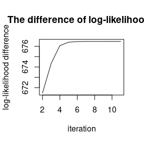

```r
plot(2:i, likelihood_o[2:i], type = "l", xlab = "iteration", ylab = "log-likelihood difference", main = "The difference of log-likelihoods")
```

Since the log-likelihood is too small to output, we just plot the The differences of log-likelihoods, which indicates that all the differences are positive, meaning the log-likelihoods are increasing.

## Exercise 3

```r
data(mtcars)
formulas <- list(
mpg ~ disp,
mpg ~ I(1 / disp),
mpg ~ disp + wt,
mpg ~ I(1 / disp) + wt
)
# for loops
for (i in formulas)
{
  model <- lm(i, data = mtcars)
  print(summary(model))
}
```

```
##
## Call:
## lm(formula = i, data = mtcars)
##
## Residuals:
##     Min      1Q  Median      3Q     Max
## -4.8922 -2.2022 -0.9631  1.6272  7.2305
##
## Coefficients:
##              Estimate Std. Error t value Pr(>|t|)
## (Intercept) 29.599855   1.229720  24.070  < 2e-16 ***
## disp        -0.041215   0.004712  -8.747 9.38e-10 ***
## ---
## Signif. codes:  0 '***' 0.001 '**' 0.01 '*' 0.05 '.' 0.1 ' ' 1
##
## Residual standard error: 3.251 on 30 degrees of freedom
## Multiple R-squared:  0.7183, Adjusted R-squared:  0.709
## F-statistic: 76.51 on 1 and 30 DF,  p-value: 9.38e-10
##
##
## Call:
## lm(formula = i, data = mtcars)
##
## Residuals:
##     Min      1Q  Median      3Q     Max
## -3.7383 -1.8216 -0.0751  1.0487  4.6105
##
## Coefficients:
##              Estimate Std. Error t value Pr(>|t|)
## (Intercept)   10.7520     0.7994   13.45 3.06e-14 ***
## I(1/disp)   1557.6739   114.8935   13.56 2.49e-14 ***
## ---
## Signif. codes:  0 '***' 0.001 '**' 0.01 '*' 0.05 '.' 0.1 ' ' 1
##
## Residual standard error: 2.295 on 30 degrees of freedom
## Multiple R-squared:  0.8597, Adjusted R-squared:  0.855
## F-statistic: 183.8 on 1 and 30 DF,  p-value: 2.494e-14
##
##
## Call:
```

[output cut: 22 more lines]

```
## Residuals:
##     Min      1Q  Median      3Q     Max
## -2.7085 -1.5121 -0.6191  1.5142  4.2314
##
## Coefficients:
##              Estimate Std. Error t value Pr(>|t|)
## (Intercept)   19.0242     3.4520   5.511 6.13e-06 ***
## I(1/disp)   1142.5600   199.8427   5.717 3.47e-06 ***
## wt            -1.7976     0.7327  -2.453   0.0204 *
## ---
## Signif. codes:  0 '***' 0.001 '**' 0.01 '*' 0.05 '.' 0.1 ' ' 1
##
## Residual standard error: 2.124 on 29 degrees of freedom
## Multiple R-squared:  0.8838, Adjusted R-squared:  0.8758
## F-statistic: 110.3 on 2 and 29 DF,  p-value: 2.788e-14
```

```r
# lapply
lm4 <- lapply(formulas, function(f) lm(f, data = mtcars))
print(lm4)
```

```
## [[1]]
##
## Call:
## lm(formula = f, data = mtcars)
##
## Coefficients:
## (Intercept)         disp
##    29.59985     -0.04122
##
##
## [[2]]
##
## Call:
## lm(formula = f, data = mtcars)
##
## Coefficients:
## (Intercept)    I(1/disp)
##       10.75      1557.67
##
##
## [[3]]
##
## Call:
## lm(formula = f, data = mtcars)
##
## Coefficients:
## (Intercept)         disp           wt
##    34.96055     -0.01772     -3.35083
##
##
## [[4]]
##
## Call:
## lm(formula = f, data = mtcars)
##
## Coefficients:
## (Intercept)    I(1/disp)           wt
##      19.024     1142.560       -1.798
```

## Exercise 3

```r
set.seed(3)
random <- replicate(100, list(rpois(10, 10), rpois(7, 10)))
locs <- 1:100
p <- sapply(locs, function(i) t.test(random[[2*i-1]], random[[2*i]])$p.value)
print(p)
```

```
##   [1] 0.592989530 0.860635317 0.457194299 0.464414050 0.861136801 0.063190547
##   [7] 0.569502932 0.756227376 0.559964309 0.181342651 0.054475511 0.404039022
##  [13] 0.028263746 0.586973905 0.417952637 0.622517735 0.962475011 0.961899636
##  [19] 0.248745081 0.292032336 0.182470055 0.235947796 0.234205401 0.290850170
##  [25] 0.681674611 0.089162807 0.645738662 0.607504699 0.531434113 0.892755819
##  [31] 0.142892712 0.369149088 0.884758267 0.630990146 0.125399860 0.626195191
##  [37] 0.084367122 0.204800311 0.893392460 0.424410366 0.663305449 0.470146902
##  [43] 0.667863051 0.945399751 0.443769951 0.008379362 0.355268873 0.323780588
##  [49] 0.788073909 0.354000303 0.712108509 0.097720743 0.062697203 0.767643566
##  [55] 0.416754708 0.070905658 0.280146392 0.486179373 0.017698942 0.309200706
##  [61] 0.524291534 0.157700776 0.913101019 0.374055340 0.552822199 0.640038892
##  [67] 0.625274377 0.217529254 0.397668201 0.339979768 0.469358999 0.663589606
##  [73] 0.132012648 0.802848226 0.911116233 0.287421841 0.225513423 0.190561294
##  [79] 0.379953570 0.992000657 0.883548073 0.724932819 0.152834596 0.720466481
##  [85] 0.719262968 0.233073377 0.942871565 0.406357343 0.035625568 0.828393863
##  [91] 0.229905702 0.929111103 0.455995640 0.741496874 0.287480071 0.935551251
##  [97] 0.968033046 0.706707747 0.621409732 0.962878707
```

## Exercise 6

```r
data(mtcars)
std <- function(x, x_bar) sum((x-x_bar)^2) / (length(x)-1)
mapva <- function(x)
{
  m <- vapply(x, mean, numeric(1))
  vapply(Map(std, x, m), unlist, numeric(1))
}
mapva(mtcars)
```

```
##          mpg          cyl         disp           hp         drat           wt
## 3.632410e+01 3.189516e+00 1.536080e+04 4.700867e+03 2.858814e-01 9.573790e-01
##         qsec           vs           am         gear         carb
## 3.193166e+00 2.540323e-01 2.489919e-01 5.443548e-01 2.608871e+00
```

## Question

Write an Rcpp function for Exercises 9.4 (page 277, Statistical Computating with R).

## Answer

The C++ code is as below:

```
# include <Rcpp.h>
# include <stdlib.h>
# include <math.h>
# define pi 3.1415926
using namespace Rcpp;

double randn()
{
  double u = ((double) rand()/(RAND_MAX));
  double v = ((double) rand()/(RAND_MAX));
  double z1 = sqrt((double)-2*log(u)) * cos((double)2*pi*v);
  if (isnan(z1))
    return (randn());
  else
    return (z1);
}

// [[Rcpp::export]]
NumericVector Metropolis(double x0, double sigma, int N)
{
  NumericVector x(N);

  x[0] = x0;
  for (int i = 1; i < N; i++)
  {
    double y = (double)(sigma*randn() + x[i-1]);
    double u = ((double) rand()/(RAND_MAX));
    if (u <= (exp(-abs(y)) / exp(-abs(x[i-1]))))
      x[i] = y;
    else
    x[i] = x[i-1];
  }
  return (x);
}
```

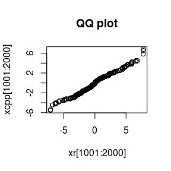

```r
library(Rcpp)
library(microbenchmark)
dir_cpp <- "../src/"
sourceCpp(paste0(dir_cpp, "Metropolis.cpp"))
rw_Metropolis <- function(x0, sigma, N)
{
  x <- numeric(N)
  x[1] <- x0
  u <- runif(N)
  for (i in 2:N)
  {
    y <- rnorm(1, x[i-1], sigma)
    if (u[i] <= exp(-abs(y))/exp(-abs(x[i-1])))
      x[i] <- y
    else
      x[i] <- x[i-1]
  }
  x
}

set.seed(123)
sigma <- 2
x0 <- 0
N <- 2000
xr <- rw_Metropolis(x0, sigma, N)
xcpp <- Metropolis(x0, sigma, N)
qqplot(xr[1001:2000], xcpp[1001:2000], main = "QQ plot")
```

The QQplot shows that the generated random numbers are in the same distribution, which means that the two algorithms could generate the same distributed random numbers.

```r
ts <- microbenchmark(rw_Metropolis(x0, sigma, N), Metropolis(x0, sigma, N))
summary(ts)
```

```
##                          expr       min         lq       mean     median
## 1 rw_Metropolis(x0, sigma, N) 12597.898 12724.0555 14173.7084 12811.5185
## 2    Metropolis(x0, sigma, N)   750.494   762.9765   807.2785   767.2395
##          uq       max neval
## 1 13040.573 24992.962   100
## 2   776.967  3743.292   100
```

The result indicates that the C++ function is much more effcient than the R function.